# **Air Quality Data in India Prediction (2015 - 2020)**

## **Contexto**

El aire es lo que mantiene vivos a los humanos. Monitorearlo y comprender su calidad es de inmensa importancia para nuestro bienestar.

## **Contenido**

El conjunto de datos contiene datos de calidad del aire y AQI (Air Quality Index) a nivel horario y diario de varias estaciones en varias ciudades de la India.

## **AQI**

Un tutorial sobre cómo calcular el **AQI** está disponible aquí: https://www.kaggle.com/rohanrao/calculating-aqi-air-quality-index

## **Ciudades**

Ahmedabad, Aizawl, Amaravati, Amritsar, Bengaluru, Bhopal, Brajrajnagar, Chandigarh, Chennai, Coimbatore, Delhi, Ernakulam, Gurugram, Guwahati, Hyderabad, Jaipur, Jorapokhar, Kochi, Kolkata, Lucknow, Mumbai, Patna, Shillong, Talcher, Thiruvananthapuram, Visakhapatnam

## **Reconocimientos**

Los datos han sido puestos a disposición del público por la Junta Central de Control de la Contaminación: https://cpcb.nic.in/, que es el portal oficial del Gobierno de la India. También tienen una aplicación de seguimiento en tiempo real: https://app.cpcbccr.com/AQI_India/

## **Resumen**

La calidad del aire tiene un impacto significativo en la salud humana y el medio ambiente. Los principales factores que afectan la calidad del aire en la India son:

- PM2.5 y PM10: Material particulado
- NO, NO2, NOx: Óxidos de nitrógeno
- NH3: Amoníaco
- CO: Monóxido de carbono
- SO2: Dióxido de azufre
- O3: Ozono
- Benceno, Tolueno, Xileno: Compuestos orgánicos volátiles

El objetivo de nuestro modelo de predicción de la calidad del aire es pronosticar con precisión el Índice de Calidad del Aire (AQI). El AQI es un indicador que muestra el nivel de contaminación del aire y sus efectos en la salud pública.

[figure not shown]

Nuestro modelo predice valores futuros de AQI en función de los niveles de diversos contaminantes que afectan la calidad del aire. Estas predicciones ayudan a los tomadores de decisiones a emitir alertas sanitarias, formular políticas ambientales, optimizar el tráfico y la gestión industrial y ayudar al público en general a planificar sus actividades diarias.

- **¿Cuál es el problema empresarial que intenta resolver mediante el aprendizaje automático?**

El problema que intenta resolver en este proyecto es predecir los valores futuros del Índice de calidad del aire (AQI) analizando los factores que afectan el AQI mediante algoritmos de aprendizaje automático. Estas predicciones se pueden utilizar para monitorear la calidad del aire y desarrollar estrategias de mejora. El objetivo es identificar el impacto de diversos parámetros contaminantes (PM2,5, PM10, NO, NO2, NOx, NH3, CO, SO2, O3, benceno, tolueno, xileno) en el ICA y pronosticar el AQI en función de los valores futuros de estos parámetros.

- **¿Por qué nos interesa solucionar este problema? ¿Qué impacto tendrá en el negocio?**

Resolver este problema es de gran importancia para la salud pública, la sostenibilidad ambiental y la protección de la biodiversidad. Predecir con precisión la calidad del aire permite a las autoridades y al público tomar medidas contra la contaminación del aire. Por ejemplo, se pueden emitir alertas y precauciones sanitarias. Se pueden desarrollar regulaciones y políticas relacionadas con la contaminación del aire. Se puede optimizar la gestión industrial y del tráfico. Al proporcionar un entorno más limpio a la sociedad, se puede mejorar la calidad de vida.

- **¿Cuáles son algunos problemas conocidos con los datos? (errores de entrada de datos, datos faltantes, diferencias de unidades, etc.)**
1. **Datos faltantes**: varias columnas, incluida la columna objetivo, tienen valores faltantes.
2. **Diferencias de unidades**: la columna Date inicialmente tenía un tipo de datos de objeto y se convirtió a Datetime.
3. **Variaciones estacionales**: los efectos estacionales pueden introducir variabilidad en los datos.

# **Modelo de Machine Learning**

### **Análisis del dataset**

```python
# Importamos librerías
import numpy as np
import pandas as pd
import matplotlib.pyplot as plt
import seaborn as sns
import datetime
from warnings import filterwarnings
filterwarnings('ignore')
```

```python
# Lectura del archivo principal
df_city_day_csv = pd.read_csv('city_day.csv')
df_city_day_csv.head()
```

|  | City | Date | PM2.5 | PM10 | NO | NO2 | NOx | NH3 | CO | SO2 | O3 | Benzene | Toluene | Xylene | AQI | AQI_Bucket |
| --- | --- | --- | --- | --- | --- | --- | --- | --- | --- | --- | --- | --- | --- | --- | --- | --- |
| 0 | Ahmedabad | 2015-01-01 | NaN | NaN | 0.92 | 18.22 | 17.15 | NaN | 0.92 | 27.64 | 133.36 | 0.00 | 0.02 | 0.00 | NaN | NaN |
| 1 | Ahmedabad | 2015-01-02 | NaN | NaN | 0.97 | 15.69 | 16.46 | NaN | 0.97 | 24.55 | 34.06 | 3.68 | 5.50 | 3.77 | NaN | NaN |
| 2 | Ahmedabad | 2015-01-03 | NaN | NaN | 17.40 | 19.30 | 29.70 | NaN | 17.40 | 29.07 | 30.70 | 6.80 | 16.40 | 2.25 | NaN | NaN |
| 3 | Ahmedabad | 2015-01-04 | NaN | NaN | 1.70 | 18.48 | 17.97 | NaN | 1.70 | 18.59 | 36.08 | 4.43 | 10.14 | 1.00 | NaN | NaN |
| 4 | Ahmedabad | 2015-01-05 | NaN | NaN | 22.10 | 21.42 | 37.76 | NaN | 22.10 | 39.33 | 39.31 | 7.01 | 18.89 | 2.78 | NaN | NaN |

```python
# Revisamos el tamaño del dataset
df_city_day_csv.shape
```

```
(29531, 16)
```

```python
# Observamos la información por columna del dataset
df_city_day_csv.info()
```

```
<class 'pandas.core.frame.DataFrame'>
RangeIndex: 29531 entries, 0 to 29530
Data columns (total 16 columns):
 #   Column      Non-Null Count  Dtype
---  ------      --------------  -----
 0   City        29531 non-null  object
 1   Date        29531 non-null  object
 2   PM2.5       24933 non-null  float64
 3   PM10        18391 non-null  float64
 4   NO          25949 non-null  float64
 5   NO2         25946 non-null  float64
 6   NOx         25346 non-null  float64
 7   NH3         19203 non-null  float64
 8   CO          27472 non-null  float64
 9   SO2         25677 non-null  float64
 10  O3          25509 non-null  float64
 11  Benzene     23908 non-null  float64
 12  Toluene     21490 non-null  float64
 13  Xylene      11422 non-null  float64
 14  AQI         24850 non-null  float64
 15  AQI_Bucket  24850 non-null  object
dtypes: float64(13), object(3)
memory usage: 3.6+ MB
```

```python
# Vemos los valores descriptivos del dataset
df_city_day_csv.describe().T
```

|  | count | mean | std | min | 25% | 50% | 75% | max |
| --- | --- | --- | --- | --- | --- | --- | --- | --- |
| PM2.5 | 24933.0 | 67.450578 | 64.661449 | 0.04 | 28.820 | 48.57 | 80.5900 | 949.99 |
| PM10 | 18391.0 | 118.127103 | 90.605110 | 0.01 | 56.255 | 95.68 | 149.7450 | 1000.00 |
| NO | 25949.0 | 17.574730 | 22.785846 | 0.02 | 5.630 | 9.89 | 19.9500 | 390.68 |
| NO2 | 25946.0 | 28.560659 | 24.474746 | 0.01 | 11.750 | 21.69 | 37.6200 | 362.21 |
| NOx | 25346.0 | 32.309123 | 31.646011 | 0.00 | 12.820 | 23.52 | 40.1275 | 467.63 |
| NH3 | 19203.0 | 23.483476 | 25.684275 | 0.01 | 8.580 | 15.85 | 30.0200 | 352.89 |
| CO | 27472.0 | 2.248598 | 6.962884 | 0.00 | 0.510 | 0.89 | 1.4500 | 175.81 |
| SO2 | 25677.0 | 14.531977 | 18.133775 | 0.01 | 5.670 | 9.16 | 15.2200 | 193.86 |
| O3 | 25509.0 | 34.491430 | 21.694928 | 0.01 | 18.860 | 30.84 | 45.5700 | 257.73 |
| Benzene | 23908.0 | 3.280840 | 15.811136 | 0.00 | 0.120 | 1.07 | 3.0800 | 455.03 |
| Toluene | 21490.0 | 8.700972 | 19.969164 | 0.00 | 0.600 | 2.97 | 9.1500 | 454.85 |
| Xylene | 11422.0 | 3.070128 | 6.323247 | 0.00 | 0.140 | 0.98 | 3.3500 | 170.37 |
| AQI | 24850.0 | 166.463581 | 140.696585 | 13.00 | 81.000 | 118.00 | 208.0000 | 2049.00 |

```python
# Función para mostrar el número de valores nulos en el dataframe y el número de valores nulos en los valores totales
def valores_nulos(df:pd.DataFrame) -> pd.DataFrame:
    val_nul = df.isnull().sum()
    val_nul_porc = 100 * df.isna().sum()/ len(df)
    val_nul_tabla = pd.concat([val_nul, val_nul_porc], axis=1)
    val_nul_tabla_ren_columnas = val_nul_tabla.rename(columns = {0 : 'Valores nulos', 1 : '% of Valores Totales'})
    return val_nul_tabla_ren_columnas

valores_nulos(df_city_day_csv)
```

|  | Valores nulos | % of Valores Totales |
| --- | --- | --- |
| City | 0 | 0.000000 |
| Date | 0 | 0.000000 |
| PM2.5 | 4598 | 15.570079 |
| PM10 | 11140 | 37.723071 |
| NO | 3582 | 12.129626 |
| NO2 | 3585 | 12.139785 |
| NOx | 4185 | 14.171549 |
| NH3 | 10328 | 34.973418 |
| CO | 2059 | 6.972334 |
| SO2 | 3854 | 13.050692 |
| O3 | 4022 | 13.619586 |
| Benzene | 5623 | 19.041008 |
| Toluene | 8041 | 27.229014 |
| Xylene | 18109 | 61.322001 |
| AQI | 4681 | 15.851139 |
| AQI_Bucket | 4681 | 15.851139 |

```python
# Convertimos la columna Date a formato datetime
df_city_day_csv['Date'] = pd.to_datetime(df_city_day_csv['Date'], format='%Y-%m-%d')
df_city_day_csv = df_city_day_csv.sort_values(by = 'Date')

df_city_day_csv['Date'].min() , df_city_day_csv['Date'].max()
```

```
(Timestamp('2015-01-01 00:00:00'), Timestamp('2020-07-01 00:00:00'))
```

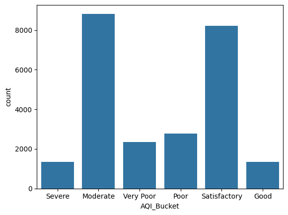

```python
# Graficamos para ver la distribución de nuestro dataset por el AQI_Bucket
sns.countplot(x=df_city_day_csv["AQI_Bucket"])
```

```python
# Borramos la columna 'AQI_Bucket' pues no es de interés para el análisis
df_city_day_csv = df_city_day_csv.drop(["AQI_Bucket"], axis=1)
```

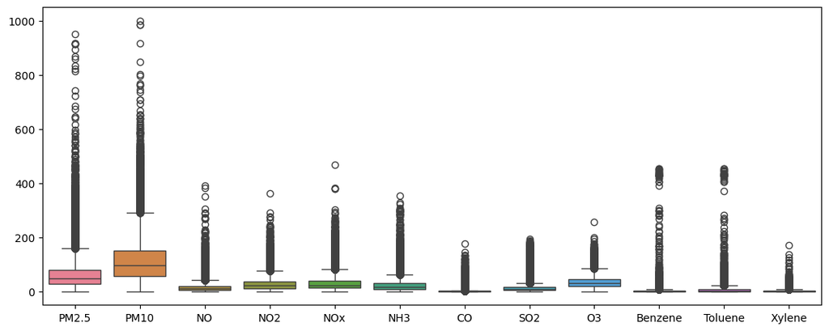

```python
#sns.boxplot(data=df_city_day_csv[['PM2.5', 'PM10', 'NO', 'NO2', 'NOx','NH3','O3', 'CO', 'SO2', 'Benzene', 'Toluene', 'Xylene']])
plt.figure(figsize = (13,5))
sns.boxplot(data=df_city_day_csv.iloc[:,2:-1])
#sns.boxplot(data=df_city_day_csv.iloc[:,8:-1])
```

### **Procesamiento de los datos**

Observamos que había demasiados valores atípicos en nuestras variables independientes. Pensamos que el modelado que haríamos con estos datos nos daría resultados incorrectos, por lo que cambiamos los valores atípicos.

```python
# Esta función toma un DataFrame como parámetro e identifica valores atípicos para las columnas numéricas en el DataFrame. Reemplaza estos
# valores atípicos con los valores de cuartil correspondientes (Q1 o Q3). Los valores atípicos se identifican mediante el rango intercuartil (IQR).
def reemplazar_outliers_con_cuartiles(df:pd.DataFrame) -> pd.DataFrame:

    for column in df.select_dtypes(include=['number']).columns:
        Q1 = df[column].quantile(0.25)
        Q3 = df[column].quantile(0.75)
        IQR = Q3 - Q1
        lower_bound = Q1 - 1.5 * IQR
        upper_bound = Q3 + 1.5 * IQR
        df[column] = df[column].apply(
            lambda x: Q1 if x < lower_bound else (Q3 if x > upper_bound else x)
        )
    return df

df_city_day_csv = reemplazar_outliers_con_cuartiles(df_city_day_csv)
```

```python
df_city_day_csv.describe().T
```

|  | count | mean | min | 25% | 50% | 75% | max | std |
| --- | --- | --- | --- | --- | --- | --- | --- | --- |
| Date | 29531 | 2018-05-14 05:40:15.807118080 | 2015-01-01 00:00:00 | 2017-04-16 00:00:00 | 2018-08-05 00:00:00 | 2019-09-03 00:00:00 | 2020-07-01 00:00:00 | NaN |
| PM2.5 | 24933.0 | 54.975923 | 0.04 | 28.82 | 48.57 | 80.59 | 158.21 | 32.781561 |
| PM10 | 18391.0 | 104.818086 | 0.01 | 56.255 | 95.68 | 149.7425 | 289.95 | 60.357602 |
| NO | 25949.0 | 12.472491 | 0.02 | 5.63 | 9.89 | 19.95 | 41.43 | 8.941774 |
| NO2 | 25946.0 | 25.482607 | 0.01 | 11.75 | 21.69 | 37.62 | 76.4 | 16.698364 |
| NOx | 25346.0 | 26.520383 | 0.0 | 12.82 | 23.52 | 40.125625 | 81.06 | 17.876378 |
| NH3 | 19203.0 | 19.661227 | 0.01 | 8.58 | 15.85 | 30.02 | 62.16 | 13.838362 |
| CO | 27472.0 | 0.952485 | 0.0 | 0.51 | 0.89 | 1.45 | 2.86 | 0.61346 |
| SO2 | 25677.0 | 10.304869 | 0.01 | 5.67 | 9.16 | 15.22 | 29.54 | 5.908036 |
| O3 | 25509.0 | 32.836577 | 0.01 | 18.86 | 30.84 | 45.57 | 85.63 | 17.969539 |
| Benzene | 23908.0 | 1.676408 | 0.0 | 0.12 | 1.07 | 3.08 | 7.52 | 1.78675 |
| Toluene | 21490.0 | 4.782706 | 0.0 | 0.6 | 2.97 | 9.15 | 21.95 | 4.962634 |
| Xylene | 11422.0 | 1.770984 | 0.0 | 0.14 | 0.98 | 3.35 | 8.15 | 1.954976 |
| AQI | 24850.0 | 146.932032 | 13.0 | 81.0 | 118.0 | 208.0 | 398.0 | 87.421731 |

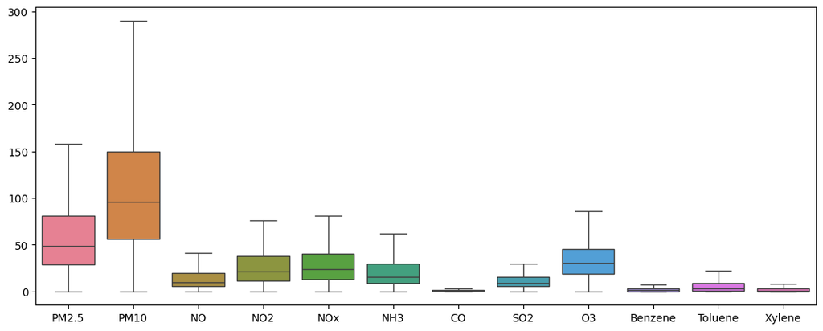

```python
plt.figure(figsize = (13,5))
sns.boxplot(data=df_city_day_csv.iloc[:,2:-1])
```

```python
df=df_city_day_csv.drop(columns=['City'])
```

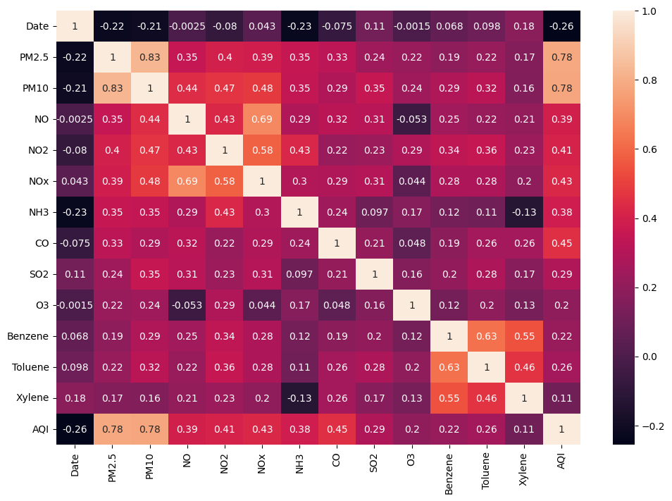

```python
plt.figure(figsize=(12, 8))
sns.heatmap(df.corr(),annot=True)
plt.show()
```

Las variables más importantes que afectan el valor del AQI parecen ser PM2,5, PM10, CO y NOx. Haremos predicciones basadas en datos superiores a 0.25.

```python
df_city_day_csv=df_city_day_csv.drop(columns=['Xylene', 'Benzene','O3'])
```

HAY VALORES NULOS EN NUESTRA COLUMNA DE AQI VARIABLE OBJETIVO, NUESTRA COLUMNA DE OBJETIVO NO PUEDE ESTAR VACÍA, POR ESO CREAMOS UN NUEVO CONJUNTO DE DATOS A PARTIR DE AQUELLOS CON AQI COMPLETO.

```python
df_full=df_city_day_csv[df_city_day_csv['AQI'].notna()]
df_full['Year'] = df_full['Date'].dt.year
df_full.head()
```

|  | City | Date | PM2.5 | PM10 | NO | NO2 | NOx | NH3 | CO | SO2 | Toluene | AQI | Year |
| --- | --- | --- | --- | --- | --- | --- | --- | --- | --- | --- | --- | --- | --- |
| 10229 | Delhi | 2015-01-01 | 80.59 | 149.745 | 19.95 | 36.39 | 40.1275 | 33.85 | 1.45 | 9.25 | 9.15 | 208.0 | 2015 |
| 10230 | Delhi | 2015-01-02 | 80.59 | 269.550 | 19.95 | 32.87 | 40.1275 | 31.83 | 1.45 | 6.65 | 20.09 | 208.0 | 2015 |
| 10231 | Delhi | 2015-01-03 | 87.18 | 131.900 | 25.73 | 30.31 | 47.9500 | 30.02 | 1.45 | 2.65 | 10.23 | 143.0 | 2015 |
| 10232 | Delhi | 2015-01-04 | 151.84 | 241.840 | 25.01 | 36.91 | 48.6200 | 30.02 | 1.45 | 4.63 | 9.71 | 319.0 | 2015 |
| 10233 | Delhi | 2015-01-05 | 146.60 | 219.130 | 14.01 | 34.92 | 38.2500 | 30.02 | 1.45 | 3.33 | 6.21 | 325.0 | 2015 |

```python
valores_nulos(df_full)
```

|  | Valores nulos | % of Valores Totales |
| --- | --- | --- |
| City | 0 | 0.000000 |
| Date | 0 | 0.000000 |
| PM2.5 | 678 | 2.728370 |
| PM10 | 7086 | 28.515091 |
| NO | 387 | 1.557344 |
| NO2 | 391 | 1.573441 |
| NOx | 1857 | 7.472837 |
| NH3 | 6536 | 26.301811 |
| CO | 445 | 1.790744 |
| SO2 | 605 | 2.434608 |
| Toluene | 5826 | 23.444668 |
| AQI | 0 | 0.000000 |
| Year | 0 | 0.000000 |

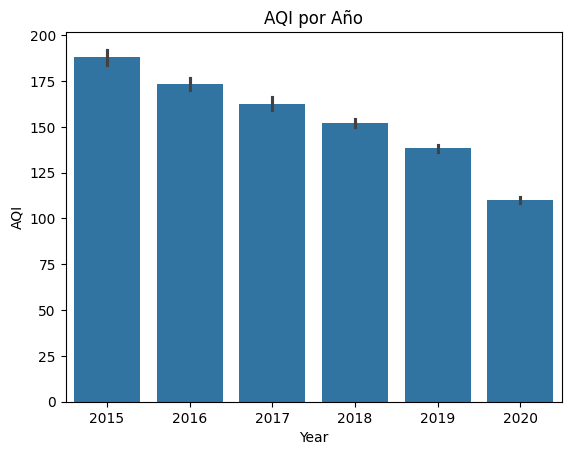

```python
plt.title('AQI por Año')
sns.barplot(x='Year',y='AQI',data=df_full);
```

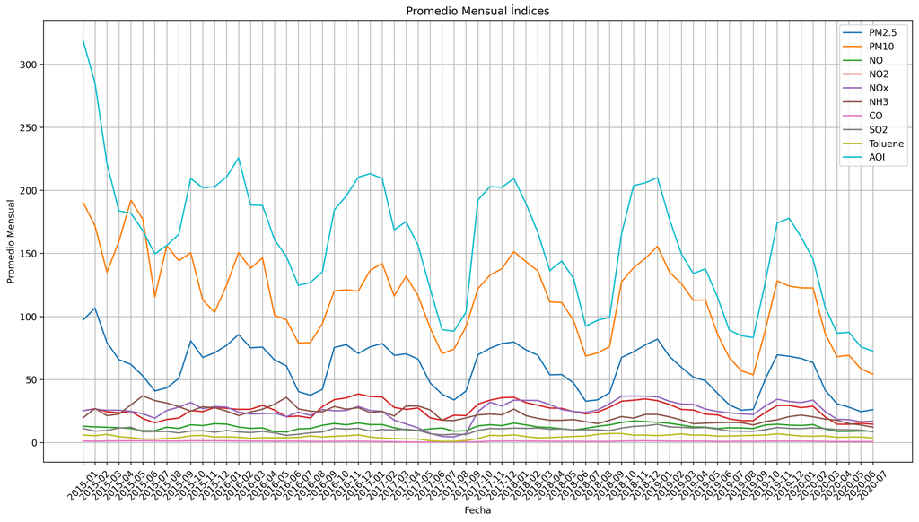

```python
numerical_cols = df_city_day_csv.select_dtypes(include='number').columns.tolist()
df_city_day_csv['Month'] = df_city_day_csv['Date'].dt.to_period('M')
monthly_data = df_city_day_csv.groupby('Month')[numerical_cols].mean(numeric_only=True)

plt.figure(figsize=(14, 8), dpi=300)
for col in numerical_cols:
    plt.plot(monthly_data.index.astype(str), monthly_data[col], label=col)

plt.xlabel('Fecha')
plt.ylabel('Promedio Mensual')
plt.title('Promedio Mensual Índices')
plt.legend()
plt.grid(True)
plt.xticks(rotation=45)
plt.tight_layout()
plt.show()
```

El gráfico de líneas de arriba es un gráfico que muestra los promedios mensuales de valores numéricos como AQI, PM10, PM2.5, NO, NO2. Según las fluctuaciones aquí observadas, se puede decir que los valores cambian según cierta estacionalidad.

Cuando nos fijamos en los intervalos estacionales de la India, se ve que diciembre y enero coinciden con la temporada de invierno. Se puede decir que el valor del AQI aumenta como resultado del aumento en el uso de combustibles como carbón, madera, aparatos de calefacción y vehículos en los meses de invierno.

El hecho de que junio y julio coincidan con el período de los monzones brinda una oportunidad para que el aire se disperse y se limpie debido al aumento de las precipitaciones y los vientos. Por este motivo, se puede decir que el valor del AQI disminuye y la calidad del aire aumenta.

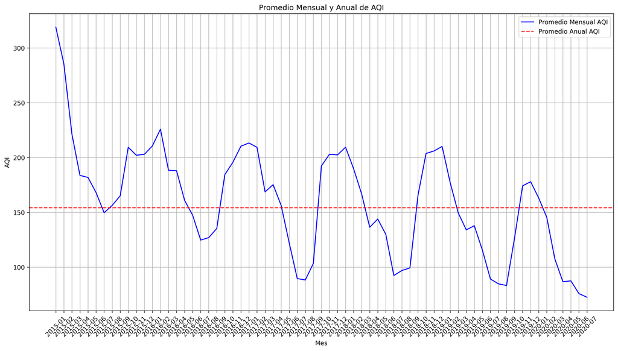

```python
df_city_day_csv['Month'] = df_city_day_csv['Date'].dt.to_period('M')
df_city_day_csv['Year'] = df_city_day_csv['Date'].dt.year

monthly_aqi = df_city_day_csv.groupby('Month')['AQI'].mean()

annual_aqi_mean = df_city_day_csv.groupby('Year')['AQI'].mean()

plt.figure(figsize=(14, 8), dpi=300)

plt.plot(monthly_aqi.index.astype(str), monthly_aqi, label='Promedio Mensual AQI', color='blue')

plt.axhline(y=annual_aqi_mean.mean(), color='red', linestyle='--', label='Promedio Anual AQI')

plt.xlabel('Mes')
plt.ylabel('AQI')
plt.title('Promedio Mensual y Anual de AQI')
plt.legend()
plt.grid(True)
plt.xticks(rotation=45)
plt.tight_layout()
plt.show()
```

El gráfico aquí es un gráfico de líneas que muestra los promedios mensuales del valor del AQI. Cuando se examina el gráfico, el valor del AQI alcanza el nivel más alto en diciembre-enero y el nivel más bajo en junio-julio. En este gráfico se puede ver que la estacionalidad es efectiva.

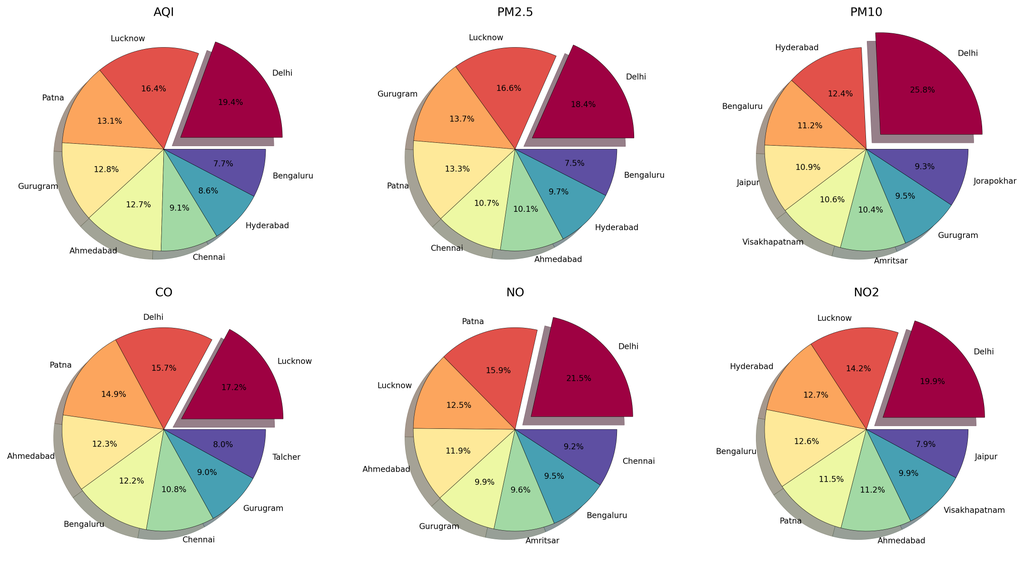

```python
cols = ['AQI', 'PM2.5', 'PM10', 'CO', 'NO', 'NO2']

cmap = plt.get_cmap('Spectral')
color = [cmap(i) for i in np.linspace(0, 1, 8)]
explode = [0.2, 0, 0, 0, 0, 0, 0, 0]

fig, axes = plt.subplots(nrows=2, ncols=3, figsize=(15, 8), dpi=300)

axes = axes.flatten()

for ax, col in zip(axes, cols):
    x = df_city_day_csv.groupby('City')[col].sum().sort_values(ascending=False)
    x = x.reset_index('City')

    top_cities = x[:8]
    sizes = top_cities[col].values
    labels = top_cities['City'].tolist()

    wedges, texts, autotexts = ax.pie(sizes, shadow=True, autopct='%1.1f%%',
                                      colors=color, explode=explode,
                                      wedgeprops={'edgecolor': 'black', 'linewidth': 0.3},
                                      labels=labels)

    for text in texts:
        text.set_fontsize(8)

    for autotext in autotexts:
        autotext.set_fontsize(8)

    ax.set_title(f'{col}')

for i in range(len(cols), len(axes)):
    fig.delaxes(axes[i])

plt.tight_layout()
plt.show()
```

En los gráficos circulares anteriores, la distribución de las ocho ciudades principales con alta contaminación del aire y el valor del AQI, así como las variables independientes que más afectan el valor del AQI, se muestran por separado por ciudad. Cuando se examina el gráfico en general, se ve que la mayor contaminación pertenece a Delhi en casi todos los gráficos. Dado que las otras distribuciones son similares entre sí, se puede decir que las variables afectan el valor del AQI de forma lineal.

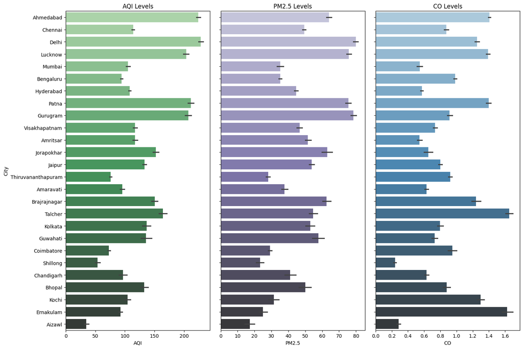

```python
fig, axes = plt.subplots(1, 3, figsize=(15, 10), sharey=True)

sns.barplot(ax=axes[0], y='City', x='AQI', data=df_city_day_csv, palette='Greens_d')
axes[0].set_title('AQI Levels')

sns.barplot(ax=axes[1], y='City', x='PM2.5', data=df_city_day_csv, palette='Purples_d')
axes[1].set_title('PM2.5 Levels')

sns.barplot(ax=axes[2], y='City', x='CO', data=df_city_day_csv, palette='Blues_d')
axes[2].set_title('CO Levels')

plt.tight_layout()
plt.show()
```

### **Preparación de los datos**

Determinar las columnas numéricas y categóricas del conjunto de datos, llenar los valores vacíos con un escalador, aplicar codificación onehot a los datos categóricos, separar el conjunto de datos en conjuntos de datos de entrenamiento, prueba y validación, determinar las columnas de entrada y de destino de los conjuntos de datos que apartado.

```python
# Asignamos los nombres de las columnas numéricas en df_city_day_csv como una lista a numeric_cols.
numeric_cols = df_full.select_dtypes(include=np.number).columns.tolist()
numeric_cols
```

```
['PM2.5',
 'PM10',
 'NO',
 'NO2',
 'NOx',
 'NH3',
 'CO',
 'SO2',
 'Toluene',
 'AQI',
 'Year']
```

```python
categorical_cols = df_full.select_dtypes(include=['object']).columns.tolist()
categorical_cols
```

```
['City']
```

```python
full_columns=df_full.columns
full_columns
```

```
Index(['City', 'Date', 'PM2.5', 'PM10', 'NO', 'NO2', 'NOx', 'NH3', 'CO', 'SO2',
       'Toluene', 'AQI', 'Year'],
      dtype='object')
```

```python
# Asignamos a input_cols de full_columns, excluyendo la última columna del índice 0 y 2.
input_cols = [full_columns[0]]+list(full_columns[2:-2])+ [full_columns[-1]]
target_col = 'AQI'
input_cols
```

```
['City',
 'PM2.5',
 'PM10',
 'NO',
 'NO2',
 'NOx',
 'NH3',
 'CO',
 'SO2',
 'Toluene',
 'Year']
```

```python
from sklearn.model_selection import train_test_split
train_and_val_df, test_df = train_test_split(df_full, test_size=0.2, random_state=42)
train_df, val_df = train_test_split(df_full, test_size=0.2)
print('train_df.shape :', train_df.shape)
print('val_df.shape :', val_df.shape)
print('test_df.shape :', test_df.shape)
```

```
train_df.shape : (19880, 13)
val_df.shape : (4970, 13)
test_df.shape : (4970, 13)
```

```python
train_df.head()
```

|  | City | Date | PM2.5 | PM10 | NO | NO2 | NOx | NH3 | CO | SO2 | Toluene | AQI | Year |
| --- | --- | --- | --- | --- | --- | --- | --- | --- | --- | --- | --- | --- | --- |
| 5723 | Bengaluru | 2018-11-30 | 43.16 | 79.92 | 10.45 | 28.44 | 30.83 | 20.64 | 0.89 | 5.46 | 1.86 | 94.0 | 2018 |
| 1530 | Ahmedabad | 2019-03-11 | 46.52 | NaN | 17.55 | 48.97 | 21.43 | NaN | 1.45 | 15.22 | 9.15 | 310.0 | 2019 |
| 13252 | Gurugram | 2018-03-28 | 88.11 | 189.37 | 27.51 | 38.23 | 41.26 | NaN | 0.83 | NaN | NaN | 191.0 | 2018 |
| 13238 | Gurugram | 2018-03-14 | 62.68 | 191.47 | 13.71 | 49.80 | 40.01 | NaN | 1.14 | NaN | NaN | 188.0 | 2018 |
| 12494 | Gurugram | 2016-02-29 | 80.59 | NaN | 8.82 | 10.73 | 7.98 | NaN | 1.49 | 6.89 | NaN | 346.0 | 2016 |

```python
val_df.head()
```

|  | City | Date | PM2.5 | PM10 | NO | NO2 | NOx | NH3 | CO | SO2 | Toluene | AQI | Year |
| --- | --- | --- | --- | --- | --- | --- | --- | --- | --- | --- | --- | --- | --- |
| 13214 | Gurugram | 2018-02-18 | 80.59 | 180.58 | 19.53 | 45.69 | 38.84 | NaN | 1.19 | NaN | NaN | 348.0 | 2018 |
| 27271 | Thiruvananthapuram | 2018-04-26 | 29.15 | 72.46 | 2.76 | 12.32 | 8.80 | 3.41 | 0.88 | 6.16 | NaN | 62.0 | 2018 |
| 14066 | Gurugram | 2020-06-19 | 65.61 | 244.35 | 4.95 | 9.00 | 10.02 | 4.43 | 0.70 | 4.15 | 2.94 | 148.0 | 2020 |
| 8665 | Chennai | 2017-04-11 | 67.15 | NaN | 3.67 | 10.53 | 7.59 | NaN | 0.00 | 4.05 | 0.00 | 117.0 | 2017 |
| 8215 | Chennai | 2016-01-17 | 55.73 | NaN | 5.82 | 10.86 | 13.78 | 30.02 | 0.67 | 2.95 | NaN | 121.0 | 2016 |

```python
test_df.head()
```

|  | City | Date | PM2.5 | PM10 | NO | NO2 | NOx | NH3 | CO | SO2 | Toluene | AQI | Year |
| --- | --- | --- | --- | --- | --- | --- | --- | --- | --- | --- | --- | --- | --- |
| 11286 | Delhi | 2017-11-23 | 80.59 | 251.23 | 34.73 | 55.04 | 70.15 | 40.03 | 1.55 | 18.32 | 11.97 | 340.0 | 2017 |
| 27868 | Thiruvananthapuram | 2019-12-14 | 17.89 | 42.06 | 8.57 | 14.27 | 14.52 | 9.53 | 1.30 | 8.33 | NaN | 78.0 | 2019 |
| 28109 | Visakhapatnam | 2016-08-10 | 23.77 | 96.36 | 18.46 | 33.73 | 30.20 | 13.62 | 1.09 | 15.22 | 9.36 | 101.0 | 2016 |
| 26662 | Talcher | 2019-09-11 | 30.58 | 83.52 | 40.31 | 6.79 | 41.69 | 8.29 | 1.24 | 15.22 | NaN | 76.0 | 2019 |
| 3109 | Amritsar | 2017-04-04 | 40.64 | 63.97 | 8.88 | 27.46 | NaN | 16.51 | 0.00 | 2.64 | NaN | 76.0 | 2017 |

```python
train_inputs = train_df[input_cols].copy()
train_target = train_df[target_col].copy()
val_inputs = val_df[input_cols].copy()
val_target = val_df[target_col].copy()
test_inputs = test_df[input_cols].copy()
test_target = test_df[target_col].copy()
```

```python
train_inputs.head()
```

|  | City | PM2.5 | PM10 | NO | NO2 | NOx | NH3 | CO | SO2 | Toluene | Year |
| --- | --- | --- | --- | --- | --- | --- | --- | --- | --- | --- | --- |
| 5723 | Bengaluru | 43.16 | 79.92 | 10.45 | 28.44 | 30.83 | 20.64 | 0.89 | 5.46 | 1.86 | 2018 |
| 1530 | Ahmedabad | 46.52 | NaN | 17.55 | 48.97 | 21.43 | NaN | 1.45 | 15.22 | 9.15 | 2019 |
| 13252 | Gurugram | 88.11 | 189.37 | 27.51 | 38.23 | 41.26 | NaN | 0.83 | NaN | NaN | 2018 |
| 13238 | Gurugram | 62.68 | 191.47 | 13.71 | 49.80 | 40.01 | NaN | 1.14 | NaN | NaN | 2018 |
| 12494 | Gurugram | 80.59 | NaN | 8.82 | 10.73 | 7.98 | NaN | 1.49 | 6.89 | NaN | 2016 |

```python
train_target
```

```
5723      94.0
1530     310.0
13252    191.0
13238    188.0
12494    346.0
         ...
13355    216.0
23721    134.0
25506    378.0
20905    342.0
18261    193.0
Name: AQI, Length: 19880, dtype: float64
```

```python
numeric_cols = train_inputs.select_dtypes(include=np.number).columns.tolist()
categorical_cols = train_inputs.select_dtypes('object').columns.tolist()
```

```python
from sklearn.impute import SimpleImputer
# Creamos un objeto imputador y especificamos que llena los valores vacíos con el promedio.
imputer =  SimpleImputer(strategy = 'mean')
# df_full entrena al imputador utilizando las columnas numéricas en el DataFrame y calcula los valores medios para cada columna.
imputer.fit(df_full[numeric_cols])
```

```
SimpleImputer()
```

```python
# El método de transformación transforma los valores faltantes en los conjuntos de entrenamiento, prueba y validación utilizando los valores
# medios aprendidos con ajuste.
train_inputs[numeric_cols] = imputer.transform(train_inputs[numeric_cols])
val_inputs[numeric_cols] = imputer.transform(val_inputs[numeric_cols])
test_inputs[numeric_cols] = imputer.transform(test_inputs[numeric_cols])
```

```python
train_inputs[numeric_cols].isna().sum()
```

```
PM2.5      0
PM10       0
NO         0
NO2        0
NOx        0
NH3        0
CO         0
SO2        0
Toluene    0
Year       0
dtype: int64
```

```python
from sklearn.preprocessing import StandardScaler

# Creamos un objeto escalador y lo ajustamos con datos de entrenamiento.
scaler = StandardScaler().fit(train_inputs[numeric_cols])
# Las columnas numéricas en los conjuntos de entrenamiento, prueba y validación están estandarizadas.
train_inputs[numeric_cols] = scaler.transform(train_inputs[numeric_cols])
val_inputs[numeric_cols] = scaler.transform(val_inputs[numeric_cols])
test_inputs[numeric_cols] = scaler.transform(test_inputs[numeric_cols])
```

```python
test_inputs.describe().T
```

|  | count | mean | std | min | 25% | 50% | 75% | max |
| --- | --- | --- | --- | --- | --- | --- | --- | --- |
| PM2.5 | 4970.0 | 0.001588 | 0.994363 | -1.697485 | -0.782718 | -0.155836 | 0.758545 | 3.160847 |
| PM10 | 4970.0 | 0.002050 | 1.003661 | -2.061575 | -0.664504 | 0.000437 | 0.370434 | 3.601722 |
| NO | 4970.0 | -0.003694 | 1.006865 | -1.408749 | -0.755752 | -0.302156 | 0.730439 | 3.262781 |
| NO2 | 4970.0 | -0.003410 | 0.994230 | -1.546370 | -0.831986 | -0.191540 | 0.702301 | 3.024012 |
| NOx | 4970.0 | -0.006989 | 0.993243 | -1.565874 | -0.748326 | -0.070431 | 0.632340 | 3.150882 |
| NH3 | 4970.0 | 0.013261 | 0.998104 | -1.664546 | -0.731728 | -0.001777 | 0.432207 | 3.510631 |
| CO | 4970.0 | 0.007611 | 1.006584 | -1.749077 | -0.699746 | -0.094530 | 0.776284 | 3.231980 |
| SO2 | 4970.0 | -0.015656 | 1.006388 | -1.782717 | -0.795013 | -0.198240 | 0.794653 | 3.320130 |
| Toluene | 4970.0 | -0.009946 | 1.006950 | -1.196243 | -0.836228 | -0.003183 | 0.454209 | 3.834797 |
| Year | 4970.0 | -0.011008 | 1.001028 | -2.082771 | -0.731858 | -0.056401 | 0.619055 | 1.294512 |

```python
df_full[categorical_cols].nunique()
```

```
City    26
dtype: int64
```

```python
from sklearn.preprocessing import OneHotEncoder

# Creamos un objeto codificador. De forma predeterminada, sparse_output = True y los resultados se devuelven en un formato disperso. Si se
# selecciona Falso, se devuelve una matriz NumPy. handle_unknown = 'ignore' Si se encuentran categorías desconocidas, no se proporciona ningún
# error y se asignan todos los valores cero para estas categorías.
encoder = OneHotEncoder(sparse_output = False, handle_unknown = 'ignore')
# Entrenamos el codificador usando las columnas categóricas en el marco de datos df_full.
encoder.fit(df_full[categorical_cols])
```

```
OneHotEncoder(handle_unknown='ignore', sparse_output=False)
```

```python
encoder.categories_
```

```
[array(['Ahmedabad', 'Aizawl', 'Amaravati', 'Amritsar', 'Bengaluru',
        'Bhopal', 'Brajrajnagar', 'Chandigarh', 'Chennai', 'Coimbatore',
        'Delhi', 'Ernakulam', 'Gurugram', 'Guwahati', 'Hyderabad',
        'Jaipur', 'Jorapokhar', 'Kochi', 'Kolkata', 'Lucknow', 'Mumbai',
        'Patna', 'Shillong', 'Talcher', 'Thiruvananthapuram',
        'Visakhapatnam'], dtype=object)]
```

```python
# Convertimos los nombres de las columnas categóricas codificadas one-hot creadas usando el objeto codificador en una lista.
encoded_cols = list(encoder.get_feature_names_out(categorical_cols))
encoded_cols
```

```
['City_Ahmedabad',
 'City_Aizawl',
 'City_Amaravati',
 'City_Amritsar',
 'City_Bengaluru',
 'City_Bhopal',
 'City_Brajrajnagar',
 'City_Chandigarh',
 'City_Chennai',
 'City_Coimbatore',
 'City_Delhi',
 'City_Ernakulam',
 'City_Gurugram',
 'City_Guwahati',
 'City_Hyderabad',
 'City_Jaipur',
 'City_Jorapokhar',
 'City_Kochi',
 'City_Kolkata',
 'City_Lucknow',
 'City_Mumbai',
 'City_Patna',
 'City_Shillong',
 'City_Talcher',
 'City_Thiruvananthapuram',
 'City_Visakhapatnam']
```

```python
train_inputs.head()
```

|  | City | PM2.5 | PM10 | NO | NO2 | NOx | NH3 | CO | SO2 | Toluene | Year |
| --- | --- | --- | --- | --- | --- | --- | --- | --- | --- | --- | --- |
| 5723 | Bengaluru | -0.373521 | -0.496902 | -0.231546 | 0.152706 | 0.228076 | 0.054111 | -0.199027 | -0.845177 | -0.769728 | -0.056401 |
| 1530 | Ahmedabad | -0.270067 | 0.000437 | 0.570579 | 1.381812 | -0.318895 | -0.001777 | 0.776284 | 0.843087 | 0.901935 | 0.619055 |
| 13252 | Gurugram | 1.010483 | 1.646713 | 1.695813 | 0.738821 | 0.834982 | -0.001777 | -0.303525 | -0.003340 | -0.003183 | -0.056401 |
| 13238 | Gurugram | 0.227497 | 1.687842 | 0.136753 | 1.431503 | 0.762246 | -0.001777 | 0.236380 | -0.003340 | -0.003183 | -0.056401 |
| 12494 | Gurugram | 0.778944 | 0.000437 | -0.415696 | -0.907570 | -1.101530 | -0.001777 | 0.845950 | -0.597819 | -0.003183 | -1.407315 |

```python
# One-hot codifica datos categóricos y agrega estos datos codificados al conjunto de datos.
train_inputs[encoded_cols] = encoder.transform(train_inputs[categorical_cols])
val_inputs[encoded_cols] = encoder.transform(val_inputs[categorical_cols])
test_inputs[encoded_cols] = encoder.transform(test_inputs[categorical_cols])
```

```python
pd.set_option('display.max_columns', None)
```

```python
test_inputs.head()
```

|  | City | PM2.5 | PM10 | NO | NO2 | NOx | NH3 | CO | SO2 | Toluene | Year | City_Ahmedabad | City_Aizawl | City_Amaravati | City_Amritsar | City_Bengaluru | City_Bhopal | City_Brajrajnagar | City_Chandigarh | City_Chennai | City_Coimbatore | City_Delhi | City_Ernakulam | City_Gurugram | City_Guwahati | City_Hyderabad | City_Jaipur | City_Jorapokhar | City_Kochi | … |
| --- | --- | --- | --- | --- | --- | --- | --- | --- | --- | --- | --- | --- | --- | --- | --- | --- | --- | --- | --- | --- | --- | --- | --- | --- | --- | --- | --- | --- | --- | --- |
| 11286 | Delhi | 0.778944 | 2.858262 | 2.511495 | 1.745215 | 2.516046 | 1.673389 | 0.950447 | 1.379318 | 1.548586 | -0.731858 | 0.0 | 0.0 | 0.0 | 0.0 | 0.0 | 0.0 | 0.0 | 0.0 | 0.0 | 0.0 | 1.0 | 0.0 | 0.0 | 0.0 | 0.0 | 0.0 | 0.0 | 0.0 | … |
| 27868 | Thiruvananthapuram | -1.151580 | -1.238403 | -0.443940 | -0.695635 | -0.720977 | -0.873697 | 0.515040 | -0.348730 | -0.003183 | 0.619055 | 0.0 | 0.0 | 0.0 | 0.0 | 0.0 | 0.0 | 0.0 | 0.0 | 0.0 | 0.0 | 0.0 | 0.0 | 0.0 | 0.0 | 0.0 | 0.0 | 0.0 | 0.0 | … |
| 28109 | Visakhapatnam | -0.970536 | -0.174919 | 0.673386 | 0.469412 | 0.191417 | -0.532137 | 0.149298 | 0.843087 | 0.950090 | -1.407315 | 0.0 | 0.0 | 0.0 | 0.0 | 0.0 | 0.0 | 0.0 | 0.0 | 0.0 | 0.0 | 0.0 | 0.0 | 0.0 | 0.0 | 0.0 | 0.0 | 0.0 | 0.0 | … |
| 26662 | Talcher | -0.760857 | -0.426395 | 3.141897 | -1.143453 | 0.860003 | -0.977250 | 0.410543 | 0.843087 | -0.003183 | 0.619055 | 0.0 | 0.0 | 0.0 | 0.0 | 0.0 | 0.0 | 0.0 | 0.0 | 0.0 | 0.0 | 0.0 | 0.0 | 0.0 | 0.0 | 0.0 | 0.0 | 0.0 | 0.0 | … |
| 3109 | Amritsar | -0.451111 | -0.809288 | -0.408918 | 0.094034 | -0.007767 | -0.290790 | -1.749077 | -1.332975 | -0.003183 | -0.731858 | 0.0 | 0.0 | 0.0 | 1.0 | 0.0 | 0.0 | 0.0 | 0.0 | 0.0 | 0.0 | 0.0 | 0.0 | 0.0 | 0.0 | 0.0 | 0.0 | 0.0 | 0.0 | … |

### **Modelado de datos**

```python
from sklearn.linear_model import LinearRegression, Ridge, Lasso, ElasticNet, SGDRegressor
from sklearn.metrics import r2_score
from sklearn.ensemble import GradientBoostingRegressor
from sklearn.svm import SVR
from sklearn.tree import DecisionTreeRegressor, plot_tree
from sklearn.ensemble import RandomForestRegressor
```

```python
# Combinamos las columnas numéricas y codificadas en caliente de los conjuntos de datos de entrenamiento, validación y prueba.
X_train = train_inputs[numeric_cols + encoded_cols]
X_val = val_inputs[numeric_cols + encoded_cols]
X_test = test_inputs[numeric_cols + encoded_cols]
```

**Predicción fija/aleatoria**

- Definamos dos modelos que siempre devuelvan los valores promedio y aleatorios como predicciones.
- Podremos determinar la puntuación mínima que deben alcanzar los modelos que crearemos con modelos dumb.

```python
# Hicimos una predicción y completamos las predicciones con el promedio de la columna AQI
def guess_mean(inputs):
    return np.full(len(inputs), df_full.AQI.mean())
```

```python
guess_mean_train_r2_score=r2_score(guess_mean(X_train), train_target)
print("El error se calculó asignando valores promedio a la predicción train_r2score: ", guess_mean_train_r2_score)
guess_mean_val_r2_score=r2_score(guess_mean(X_val), val_target)
print("El error se calculó asignando valores promedio a la predicción val_r2score : ", guess_mean_val_r2_score)
guess_mean_test_r2_score=r2_score(guess_mean(X_test), test_target)
print("El error se calculó asignando valores promedio a la predicción test_r2score: ", guess_mean_test_r2_score)
```

```
El error se calculó asignando valores promedio a la predicción train_r2score:  -9.554737704527923e+30
El error se calculó asignando valores promedio a la predicción val_r2score :  0.0
El error se calculó asignando valores promedio a la predicción test_r2score:  0.0
```

```python
# Hicimos una predicción y completamos las predicciones con valores aleatorios entre los valores más bajo y más alto de la columna AQI.
def guess_random(inputs):
    lo, hi = df_full.AQI.min(), df_full.AQI.max()
    return np.random.random(len(inputs)) * (hi - lo) + lo
```

```python
guess_random_train_r2_score=r2_score(guess_random(X_train), train_target)
print("El error se calculó asignando valores promedio a la predicción train_r2_score: ", guess_random_train_r2_score)
guess_random_val_r2_score=r2_score(guess_random(X_val), val_target)
print("El error se calculó asignando valores promedio a la predicción val_r2_score : ", guess_random_val_r2_score)
guess_random_test_r2_score=r2_score(guess_random(X_test), test_target)
print("El error se calculó asignando valores promedio a la predicción test_r2_score : ", guess_random_test_r2_score)
```

```
El error se calculó asignando valores promedio a la predicción train_r2_score:  -0.9001511696904314
El error se calculó asignando valores promedio a la predicción val_r2_score :  -0.8873401016770213
El error se calculó asignando valores promedio a la predicción test_r2_score :  -0.8655958550456522
```

- La puntuación R² de los datos de entrenamiento indica que la capacidad del modelo para explicar la variabilidad en los datos de calidad del aire es muy baja. Esto significa que el modelo no está aprendiendo eficazmente las relaciones entre la contaminación del aire y otros factores de la calidad del aire.
- Si las puntuaciones R² para los conjuntos de entrenamiento, validación y prueba tienen aproximadamente el mismo valor negativo, indica que el modelo tuvo un desempeño deficiente en los tres conjuntos de datos, lo que significa que no se estaba sobreajustando o subajustando, sino que el modelo estaba simplemente incorrecto.

```python
results = []
#creamos un diccionario donde creamos objetos de diferentes modelos
models = {
    'LinearRegression': LinearRegression(),
    'Ridge': Ridge(),
    'SGDRegressor' : SGDRegressor(),
    'ElasticNet':ElasticNet(),
    'Lasso' : Lasso(),
    'SVR' :SVR(kernel='linear'),
    'GradientBoostingRegressor': GradientBoostingRegressor(random_state=42)
}
```

```python
def try_model(model,name):
    model.fit(X_train, train_target)
    train_preds = model.predict(X_train)
    val_preds = model.predict(X_val)
    test_preds=model.predict(X_test)

    # La puntuación R^2 indica qué tan bien predijo el modelo. Un valor cercano a 1 indica que el modelo predijo perfectamente.
    train_r2_score = r2_score(train_target, train_preds)
    val_r2_score= r2_score(val_target, val_preds)
    test_r2_score = r2_score(test_target, test_preds)

    print(f"{name} Modelo:")
    print("Entrenamiento r2_score : ", train_r2_score)
    print("Validación r2_score : ", val_r2_score)
    print("Prueba r2_score : ", test_r2_score)
    print("-" * 40)
    # Agregamos el nombre de cada modelo y las puntuaciones de ese modelo a la lista de resultados.
    results.append({'Modelo': name,
                    'Entrenamiento R2 Score': train_r2_score,
                    'Validación R2 Score': val_r2_score,
                    'Test R2 Score': test_r2_score})
```

```python
# Entrena y prueba cada modelo
for name, model in models.items():
    try_model(model,name)
```

```
LinearRegression Modelo:
Entrenamiento r2_score :  0.7099933119596957
Validación r2_score :  0.6993170833045133
Prueba r2_score :  0.70628395205603
----------------------------------------
Ridge Modelo:
Entrenamiento r2_score :  0.7099933624698443
Validación r2_score :  0.6993271672000223
Prueba r2_score :  0.7062819377848516
----------------------------------------
SGDRegressor Modelo:
Entrenamiento r2_score :  0.7097929892143333
Validación r2_score :  0.6991119171974538
Prueba r2_score :  0.7059287474658894
----------------------------------------
ElasticNet Modelo:
Entrenamiento r2_score :  0.6417084683088745
Validación r2_score :  0.6389993188619916
Prueba r2_score :  0.6402309916325426
----------------------------------------
Lasso Modelo:
Entrenamiento r2_score :  0.6885489928050422
Validación r2_score :  0.6831150315940416
Prueba r2_score :  0.6870717124722132
----------------------------------------
SVR Modelo:
Entrenamiento r2_score :  0.6863682971318028
Validación r2_score :  0.6781154272333546
Prueba r2_score :  0.6852233441467996
----------------------------------------
GradientBoostingRegressor Modelo:
Entrenamiento r2_score :  0.8401584486132757
Validación r2_score :  0.83030890750832
Prueba r2_score :  0.841131844301711
----------------------------------------
```

```python
from sklearn.tree import DecisionTreeRegressor, plot_tree
tree = DecisionTreeRegressor(random_state=42)
try_model(tree,name="DecisionTreeRegressor")
```

```
DecisionTreeRegressor Modelo:
Entrenamiento r2_score :  0.9998874683143738
Validación r2_score :  0.7211617594203763
Prueba r2_score :  0.9499740198460184
----------------------------------------
```

[output not shown]

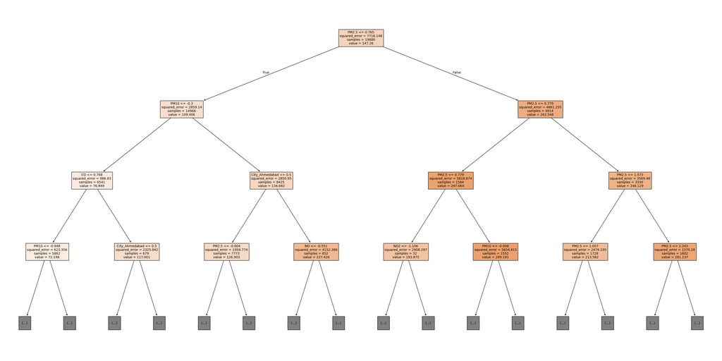

```python
plt.figure(figsize=(40, 20))
# El parámetro max_depth=3 especifica 3 nivel de profundidad, filled=True colorea los 3 nodos,
# el parametro feature_names=numeric_cols+encoded_cols especifica los nombres de las características.
plot_tree(tree, max_depth=3, filled=True, feature_names=numeric_cols+encoded_cols)
```

```python
# Realiza predicciones utilizando un bosque de árboles de decisión.. El parámetro n_jobs=-1 especifica el npumero de núcleos usados en el
# modelo de entrenamiento. -1 garantiza que se utilicen todos los núcleos y que la capacitación del modelo se pueda completar en un tiempo
# más corto.
rf = RandomForestRegressor(random_state=42, n_jobs=-1)
try_model(rf,name="RandomForestRegressor")
```

```
RandomForestRegressor Modelo:
Entrenamiento r2_score :  0.9797414924314775
Validación r2_score :  0.8504441049929067
Prueba r2_score :  0.9588228975850077
----------------------------------------
```

```python
rf.feature_importances_
```

```
array([6.60368147e-01, 1.14736501e-01, 2.52487232e-02, 2.07681850e-02,
       1.63895281e-02, 1.20227279e-02, 3.54429166e-02, 2.06163460e-02,
       1.53233104e-02, 1.07672370e-02, 4.91687589e-02, 4.20245484e-06,
       1.14210792e-04, 7.20590189e-04, 1.89232216e-03, 1.76776600e-04,
       2.77957376e-04, 5.38700912e-05, 1.91228452e-03, 5.24196953e-05,
       5.92871390e-03, 2.75468923e-05, 1.17467487e-03, 5.35386861e-04,
       1.34788056e-03, 5.04366055e-04, 2.66342743e-04, 4.72264995e-05,
       3.17960288e-04, 1.17449834e-03, 9.50296465e-05, 1.29296094e-03,
       4.10353753e-06, 8.89173949e-04, 8.28689187e-05, 2.54250918e-04])
```

```python
importance_df = pd.DataFrame({
    'feature': numeric_cols+encoded_cols,
    'importance': rf.feature_importances_
}).sort_values('importance', ascending=False)
importance_df.head(10)
```

|  | feature | importance |
| --- | --- | --- |
| 0 | PM2.5 | 0.660368 |
| 1 | PM10 | 0.114737 |
| 10 | City_Ahmedabad | 0.049169 |
| 6 | CO | 0.035443 |
| 2 | NO | 0.025249 |
| 3 | NO2 | 0.020768 |
| 7 | SO2 | 0.020616 |
| 4 | NOx | 0.016390 |
| 8 | Toluene | 0.015323 |
| 5 | NH3 | 0.012023 |

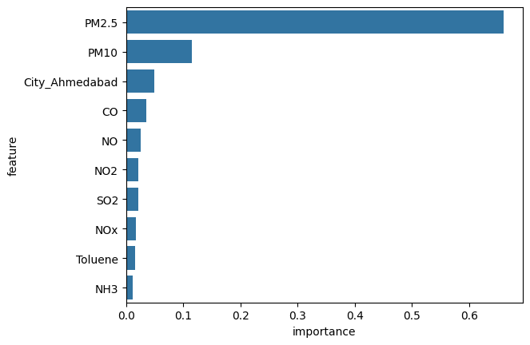

```python
sns.barplot(data=importance_df.head(10), x='importance', y='feature')
```

- Descubrimos que el modelo GradientBoostingRegressor es adecuado para nuestro conjunto de datos. Intentamos encontrar el mejor modelo optimizando los hiperparámetros del modelo utilizando RandomizedSearchCV.

```python
GBR = GradientBoostingRegressor()
param_distributions = {
    'n_estimators': [50, 100, 200, 300],
    'learning_rate': [0.001, 0.01, 0.1, 0.2],
    'max_depth': [3, 4, 5, 6],
    'min_samples_split': [2, 5, 10],
    'min_samples_leaf': [1, 2, 4],
    'subsample': [0.8, 0.9, 1.0]
}
```

```python
# Usamos RandomizedSearchCV para optimizar los hiperparámetros del modelo GradientBoostingRegressor
from sklearn.model_selection import RandomizedSearchCV
randomized_search = RandomizedSearchCV(
    estimator=GBR,
    param_distributions=param_distributions,
    n_iter=10,
    cv=5,
    verbose=1,
    n_jobs=-1,
    random_state=42
)

randomized_search.fit(X_train, train_target)
```

```
Fitting 5 folds for each of 10 candidates, totalling 50 fits
```

```
RandomizedSearchCV(cv=5, estimator=GradientBoostingRegressor(), n_jobs=-1,
                   param_distributions={'learning_rate': [0.001, 0.01, 0.1,
                                                          0.2],
                                        'max_depth': [3, 4, 5, 6],
                                        'min_samples_leaf': [1, 2, 4],
                                        'min_samples_split': [2, 5, 10],
                                        'n_estimators': [50, 100, 200, 300],
                                        'subsample': [0.8, 0.9, 1.0]},
                   random_state=42, verbose=1)
```

```python
print("Mejores Hiperparámetros :", randomized_search.best_params_)
print("Mejor Score :", randomized_search.best_score_)
```

```
Mejores Hiperparámetros : {'subsample': 0.9, 'n_estimators': 300, 'min_samples_split': 10, 'min_samples_leaf': 4, 'max_depth': 6, 'learning_rate': 0.1}
Mejor Score : 0.8525926622208079
```

```python
best_model = randomized_search.best_estimator_
best_model.fit(X_train, train_target)
train_preds = best_model.predict(X_train)
val_preds = best_model.predict(X_val)
test_preds=best_model.predict(X_test)

train_r2_score = r2_score(train_target, train_preds)
val_r2_score= r2_score(val_target, val_preds)
test_r2_score = r2_score(test_target, test_preds)

print("Entrenamiento r2_score : ", train_r2_score)
print("Validación r2_score : ", val_r2_score)
print("Prueba r2_score : ", test_r2_score)
```

```
Entrenamiento r2_score :  0.9304467408236026
Validación r2_score :  0.8520138777573729
Prueba r2_score :  0.9167857294494387
```

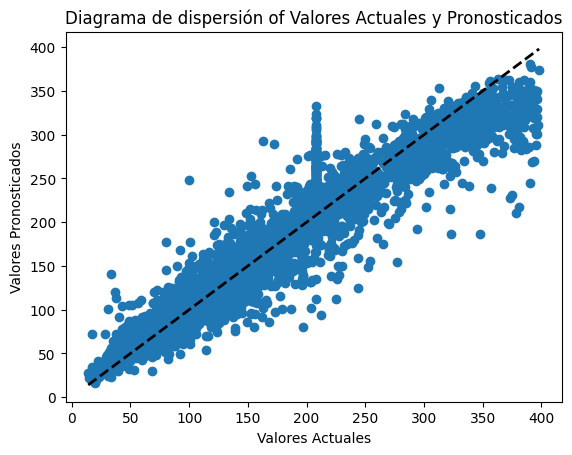

```python
def plot_actual_predict_graph(test_target,test_preds):
    # Scatter plot
    plt.scatter(test_target, test_preds)
    plt.plot([min(test_target), max(test_target)], [min(test_target), max(test_target)], 'k--', lw=2)
    plt.xlabel('Valores Actuales')
    plt.ylabel('Valores Pronosticados')
    plt.title('Diagrama de dispersión of Valores Actuales y Pronosticados')
    plt.show()

plot_actual_predict_graph(test_target,test_preds)
```

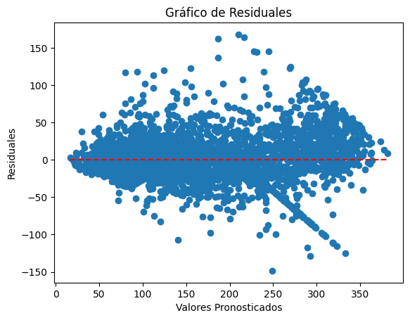

```python
def plot_residual_graph(test_target,test_preds):
    #We assign the difference between the target and the prediction to the resiuals variable
    residuals = test_target - test_preds
#each point represents (x=predicted value, y=residual of that value).
    plt.scatter(test_preds, residuals)
    plt.hlines(0, min(test_preds), max(test_preds), colors='r', linestyles='dashed') # we drew y= 0 line
    plt.xlabel('Valores Pronosticados')
    plt.ylabel('Residuales')
    plt.title('Gráfico de Residuales')
    plt.show()

plot_residual_graph(test_target,test_preds)
```

```python
#Escribimos una función para predecir cuándo se ingresan datos externos.
def predict_input(single_input, model):
    input_df = pd.DataFrame([single_input])
    input_df['Date'] = pd.to_datetime(input_df['Date'], format='%d-%m-%Y')
    input_df['Year'] = input_df['Date'].dt.year
    input_df[numeric_cols] = imputer.transform(input_df[numeric_cols])
    input_df[numeric_cols] = scaler.transform(input_df[numeric_cols])
    input_df[encoded_cols] = encoder.transform(input_df[categorical_cols])
    X_input = input_df[numeric_cols + encoded_cols]
    pred = model.predict(X_input)[0]
    return pred
```

```python
#Creamos un input como entrada de datos única.
new_input = {'City': 'Delhi',
             'PM2.5': 23.2,
             'PM10': 33.2,
             'NO': 10.2,
             'NO2': 4.2,
             'NOx': 10.4,
             'NH3': 52.0,
             'CO': 13.0,
             'SO2': 20.0,
             'Toluene': 89.0,
             'Date': '01-01-2019',
           }

predict_input(new_input, best_model)
```

```
171.72725424817185
```

```python
results_df = pd.DataFrame(results)
results_df
```

|  | Modelo | Entrenamiento R2 Score | Validación R2 Score | Test R2 Score |
| --- | --- | --- | --- | --- |
| 0 | LinearRegression | 0.709993 | 0.699317 | 0.706284 |
| 1 | Ridge | 0.709993 | 0.699327 | 0.706282 |
| 2 | SGDRegressor | 0.709793 | 0.699112 | 0.705929 |
| 3 | ElasticNet | 0.641708 | 0.638999 | 0.640231 |
| 4 | Lasso | 0.688549 | 0.683115 | 0.687072 |
| 5 | SVR | 0.686368 | 0.678115 | 0.685223 |
| 6 | GradientBoostingRegressor | 0.840158 | 0.830309 | 0.841132 |
| 7 | DecisionTreeRegressor | 0.999887 | 0.721162 | 0.949974 |
| 8 | RandomForestRegressor | 0.979741 | 0.850444 | 0.958823 |

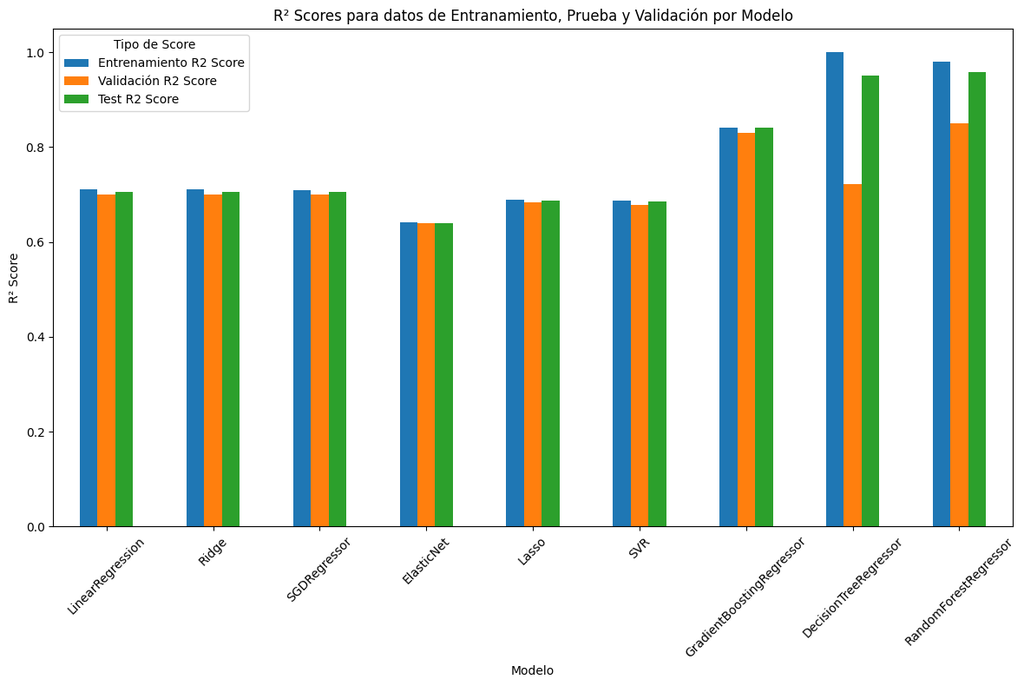

```python
# Visualizando los resultados
results_df.set_index('Modelo').plot(kind='bar', figsize=(12, 8))
plt.title('R² Scores para datos de Entranamiento, Prueba y Validación por Modelo')
plt.xlabel('Modelo')
plt.ylabel('R² Score')
plt.legend(title='Tipo de Score')
plt.xticks(rotation=45)
plt.tight_layout()
plt.show()
```

### **Guardar modelo y cargarlo nuevamente**

```python
from joblib import dump, load

dump(best_model, 'modelo_calidad_aire.pkl')
```

```
['modelo_calidad_aire.pkl']
```

```python
modelo_cargado = load('modelo_calidad_aire.pkl')
predict_input(new_input, modelo_cargado)
```

```
171.72725424817185
```